# List of Figures

Olya Gnilova

16 05 2018

## Random Variables

Figure

File Name

Link

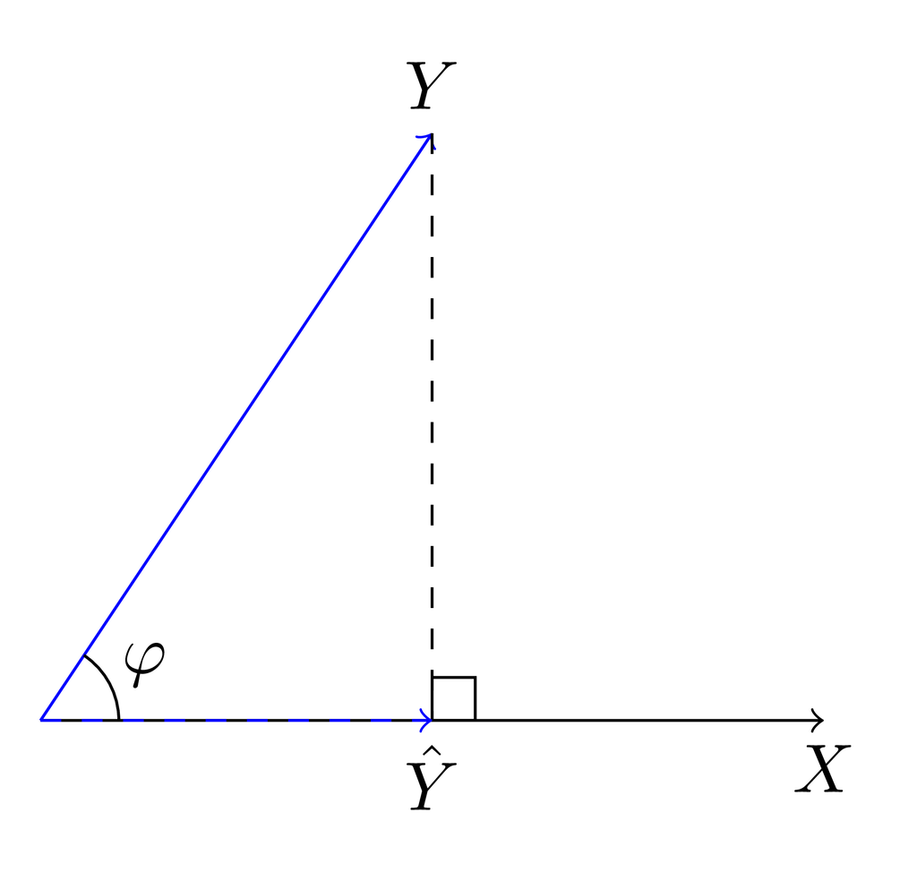

01_basic_projection

[TeX](https://github.com/olyagnilova/gauss-markov-pythagoras/blob/master/figures/01_basic_projection.tex) [PDF](https://github.com/olyagnilova/gauss-markov-pythagoras/blob/master/figures/01_basic_projection.pdf) [PNG](https://github.com/olyagnilova/gauss-markov-pythagoras/blob/master/figures/01_basic_projection.png) [SVG](https://github.com/olyagnilova/gauss-markov-pythagoras/blob/master/figures/01_basic_projection.svg)

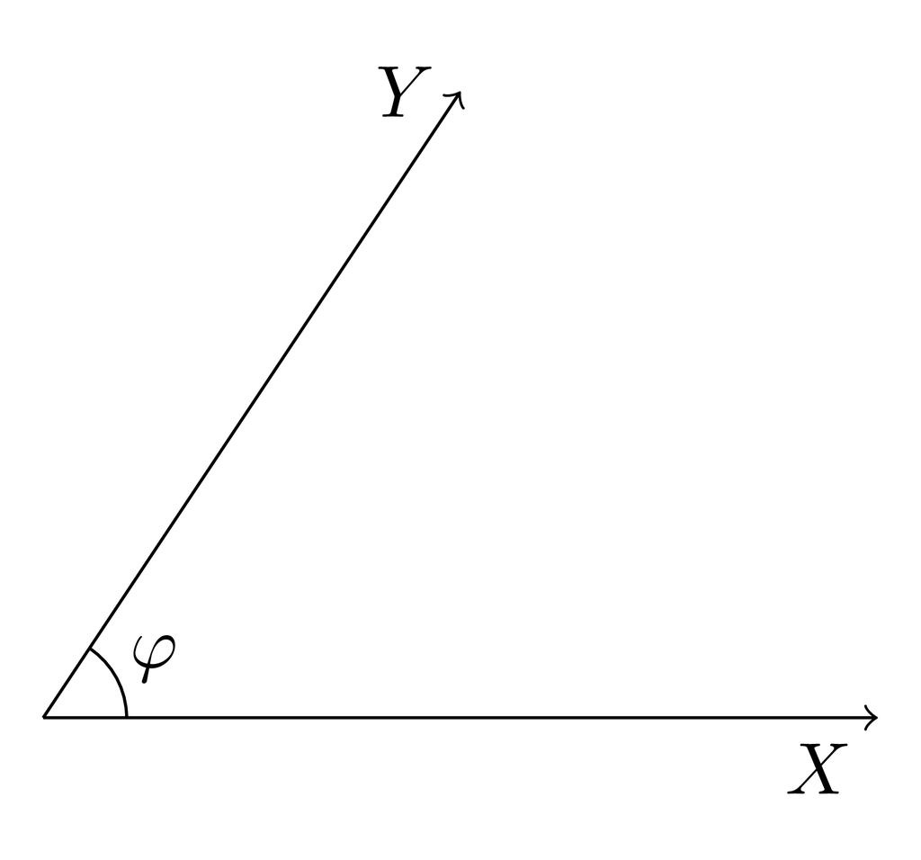

01_corr_def

[TeX](https://github.com/olyagnilova/gauss-markov-pythagoras/blob/master/figures/01_corr_def.tex) [PDF](https://github.com/olyagnilova/gauss-markov-pythagoras/blob/master/figures/01_corr_def.pdf) [PNG](https://github.com/olyagnilova/gauss-markov-pythagoras/blob/master/figures/01_corr_def.png) [SVG](https://github.com/olyagnilova/gauss-markov-pythagoras/blob/master/figures/01_corr_def.svg)

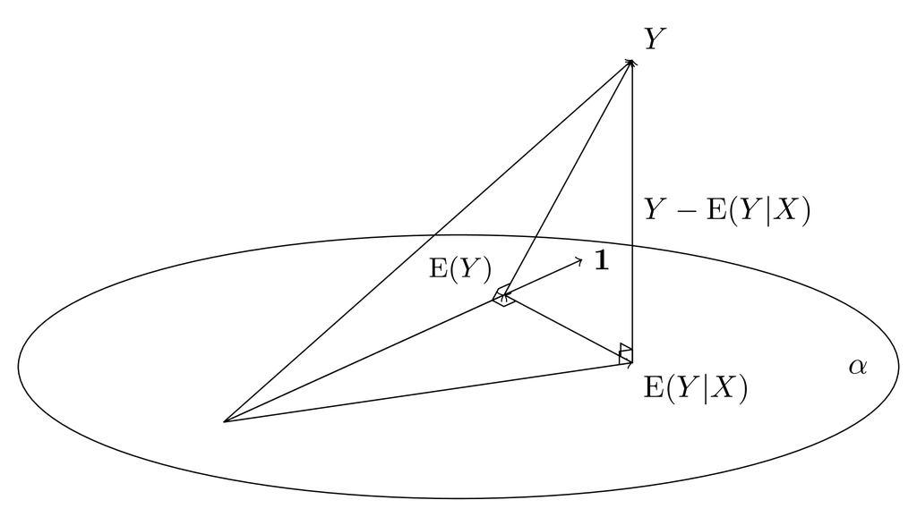

01_law_of_iterated_expectations

[TeX](https://github.com/olyagnilova/gauss-markov-pythagoras/blob/master/figures/01_law_of_iterated_expectations.tex) [PDF](https://github.com/olyagnilova/gauss-markov-pythagoras/blob/master/figures/01_law_of_iterated_expectations.pdf) [PNG](https://github.com/olyagnilova/gauss-markov-pythagoras/blob/master/figures/01_law_of_iterated_expectations.png)

[SVG](https://github.com/olyagnilova/gauss-markov-pythagoras/blob/master/figures/01_law_of_iterated_expectations.svg)

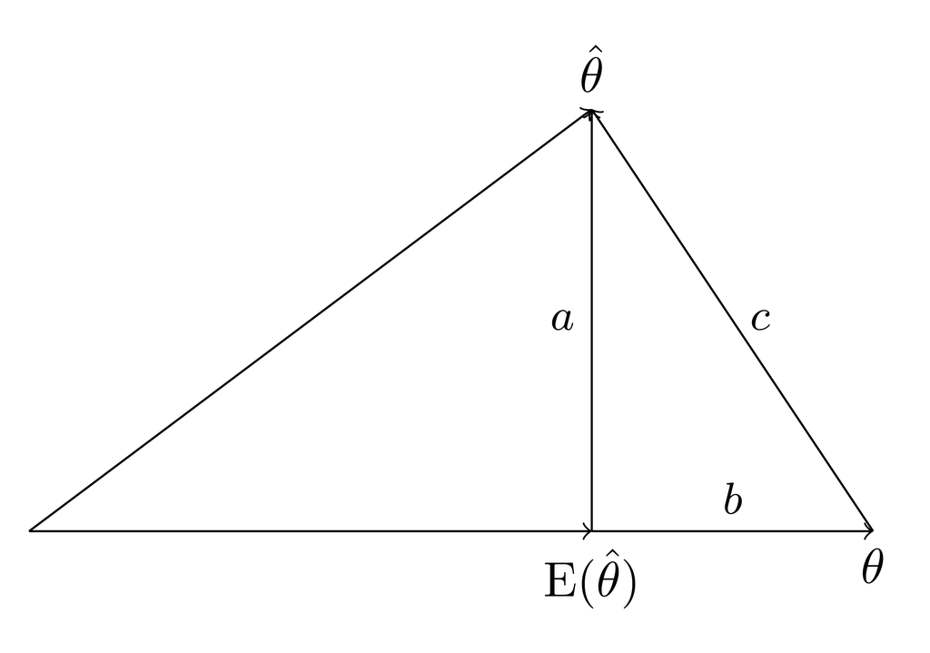

[output not shown]

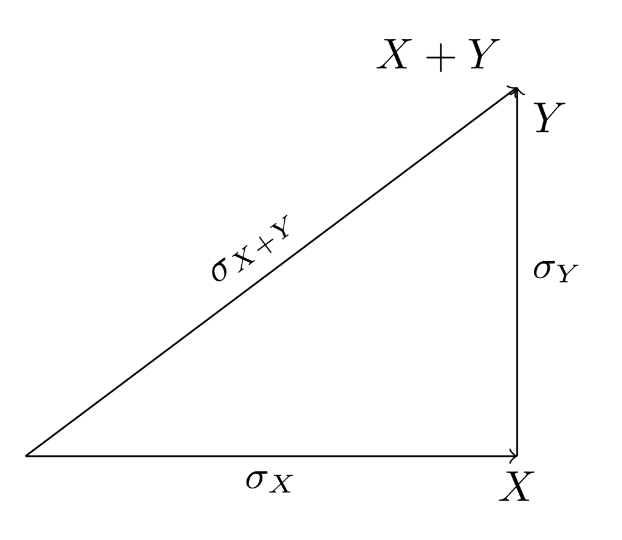

| 01_pythagorean_theorem | [TeX](https://github.com/olyagnilova/gauss-markov-pythagoras/blob/master/figures/01_pythagorean_theorem.tex) [PDF](https://github.com/olyagnilova/gauss-markov-pythagoras/blob/master/figures/01_pythagorean_theorem.pdf) [PNG](https://github.com/olyagnilova/gauss-markov-pythagoras/blob/master/figures/01_pythagorean_theorem.png) [SVG](https://github.com/olyagnilova/gauss-markov-pythagoras/blob/master/figures/01_pythagorean_theorem.svg)

## Regression

Figure

File Name

Link

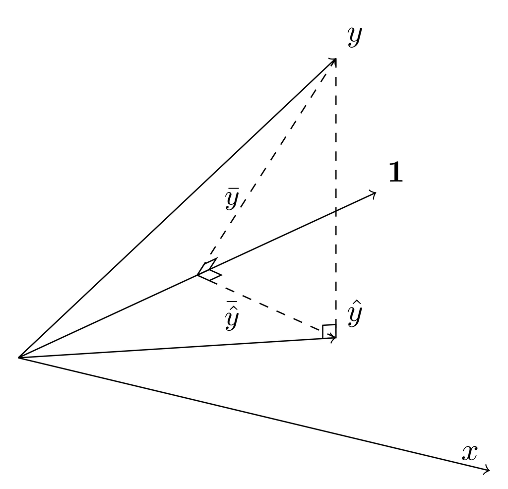

02_averages_final

[TeX](https://github.com/olyagnilova/gauss-markov-pythagoras/blob/master/figures/02_averages_final.tex) [PDF](https://github.com/olyagnilova/gauss-markov-pythagoras/blob/master/figures/02_averages_final.pdf) [PNG](https://github.com/olyagnilova/gauss-markov-pythagoras/blob/master/figures/02_averages_final.png) [SVG](https://github.com/olyagnilova/gauss-markov-pythagoras/blob/master/figures/02_averages_final.svg)

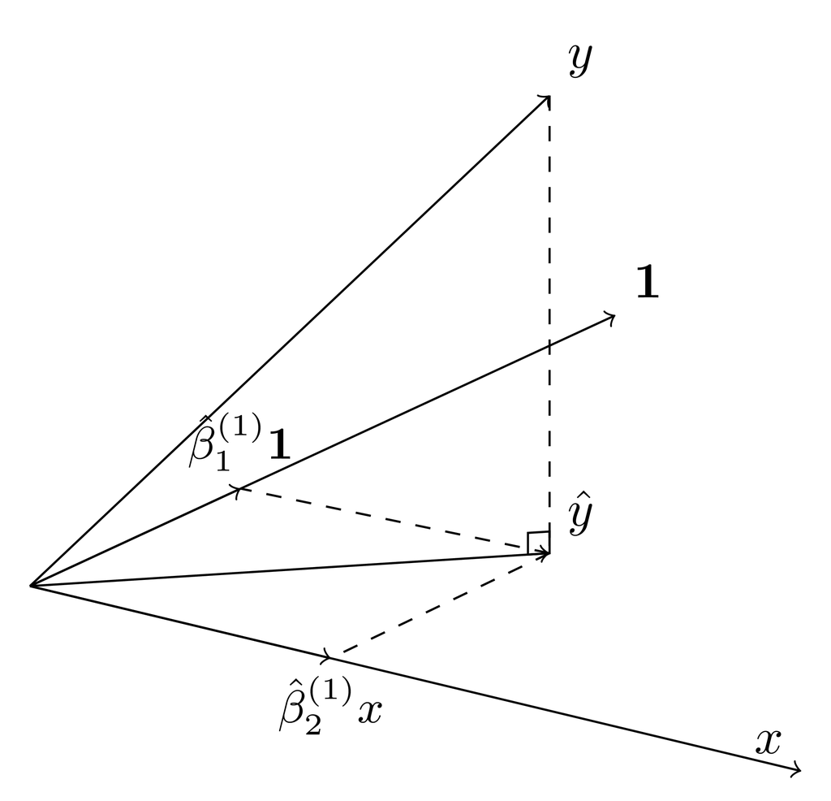

02_averages_yhat_decomposed

[TeX](https://github.com/olyagnilova/gauss-markov-pythagoras/blob/master/figures/02_averages_yhat_decomposed.tex) [PDF](https://github.com/olyagnilova/gauss-markov-pythagoras/blob/master/figures/02_averages_yhat_decomposed.pdf) [PNG](https://github.com/olyagnilova/gauss-markov-pythagoras/blob/master/figures/02_averages_yhat_decomposed.png) [SVG](https://github.com/olyagnilova/gauss-markov-pythagoras/blob/master/figures/02_averages_yhat_decomposed.svg)

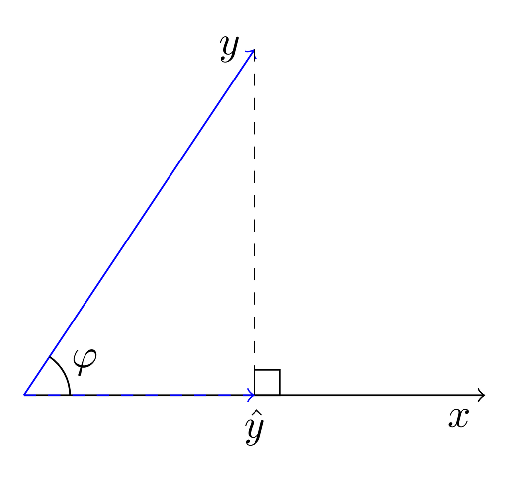

02_basic_projection

[TeX](https://github.com/olyagnilova/gauss-markov-pythagoras/blob/master/figures/02_basic_projection.tex) [PDF](https://github.com/olyagnilova/gauss-markov-pythagoras/blob/master/figures/02_basic_projection.pdf) [PNG](https://github.com/olyagnilova/gauss-markov-pythagoras/blob/master/figures/02_basic_projection.png) [SVG](https://github.com/olyagnilova/gauss-markov-pythagoras/blob/master/figures/02_basic_projection.svg)

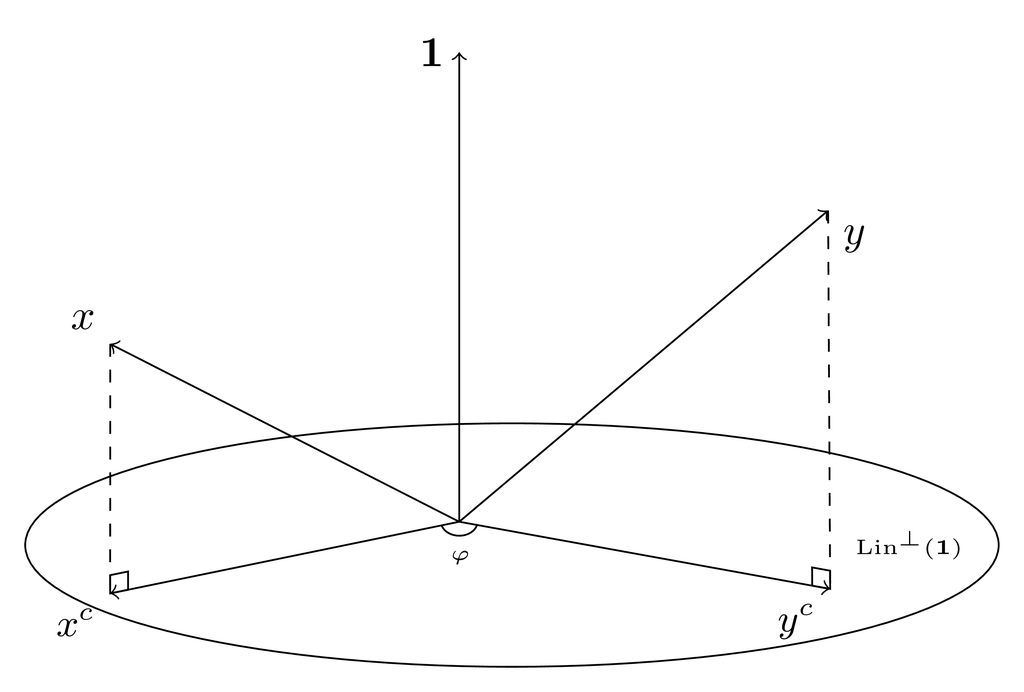

02_correlation_constant_centere_variables

[TeX](https://github.com/olyagnilova/gauss-markov-pythagoras/blob/master/figures/02_correlation_constant_centered_variables.tex) [PDF](https://github.com/olyagnilova/gauss-markov-pythagoras/blob/master/figures/02_correlation_constant_centered_variables.pdf) [PNG](https://github.com/olyagnilova/gauss-markov-pythagoras/blob/master/figures/02_correlation_constant_centered_variables.png) [SVG](https://github.com/olyagnilova/gauss-markov-pythagoras/blob/master/figures/02_correlation_constant_centered_variables.svg)

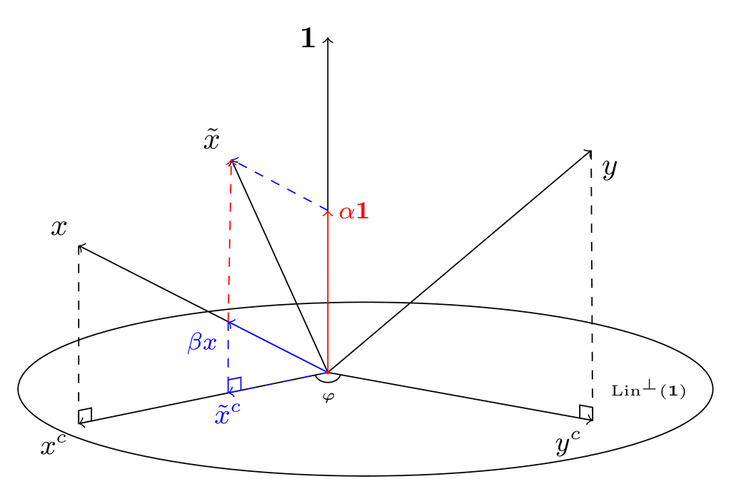

02_correlation_constant_decomposition

[TeX](https://github.com/olyagnilova/gauss-markov-pythagoras/blob/master/figures/02_correlation_constant_decomposition.tex) [PDF](https://github.com/olyagnilova/gauss-markov-pythagoras/blob/master/figures/02_correlation_constant_decomposition.pdf) [PNG](https://github.com/olyagnilova/gauss-markov-pythagoras/blob/master/figures/02_correlation_constant_decomposition.png) [SVG](https://github.com/olyagnilova/gauss-markov-pythagoras/blob/master/figures/02_correlation_constant_decomposition.svg)

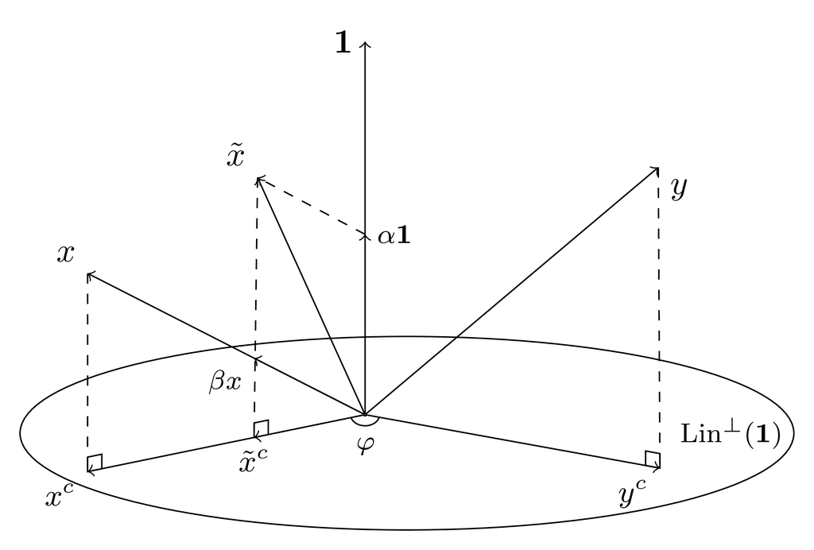

02_correlation_constant_proof

[TeX](https://github.com/olyagnilova/gauss-markov-pythagoras/blob/master/figures/02_correlation_constant_proof.tex) [PDF](https://github.com/olyagnilova/gauss-markov-pythagoras/blob/master/figures/02_correlation_constant_proof.pdf) [PNG](https://github.com/olyagnilova/gauss-markov-pythagoras/blob/master/figures/02_correlation_constant_proof.png) [SVG](https://github.com/olyagnilova/gauss-markov-pythagoras/blob/master/figures/02_correlation_constant_proof.svg)

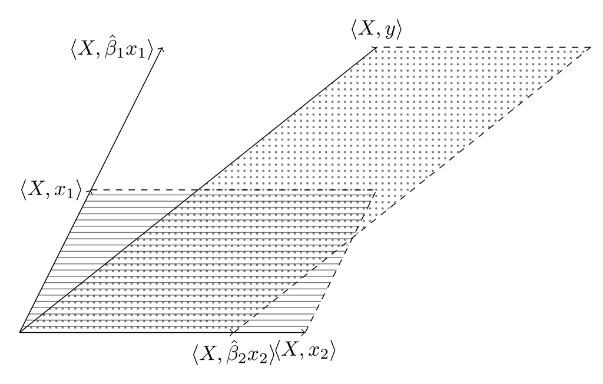

02_cramers_rule

[TeX](https://github.com/olyagnilova/gauss-markov-pythagoras/blob/master/figures/02_cramers_rule.tex) [PDF](https://github.com/olyagnilova/gauss-markov-pythagoras/blob/master/figures/02_cramers_rule.pdf) [PNG](https://github.com/olyagnilova/gauss-markov-pythagoras/blob/master/figures/02_cramers_rule.png) [SVG](https://github.com/olyagnilova/gauss-markov-pythagoras/blob/master/figures/02_cramers_rule.svg)

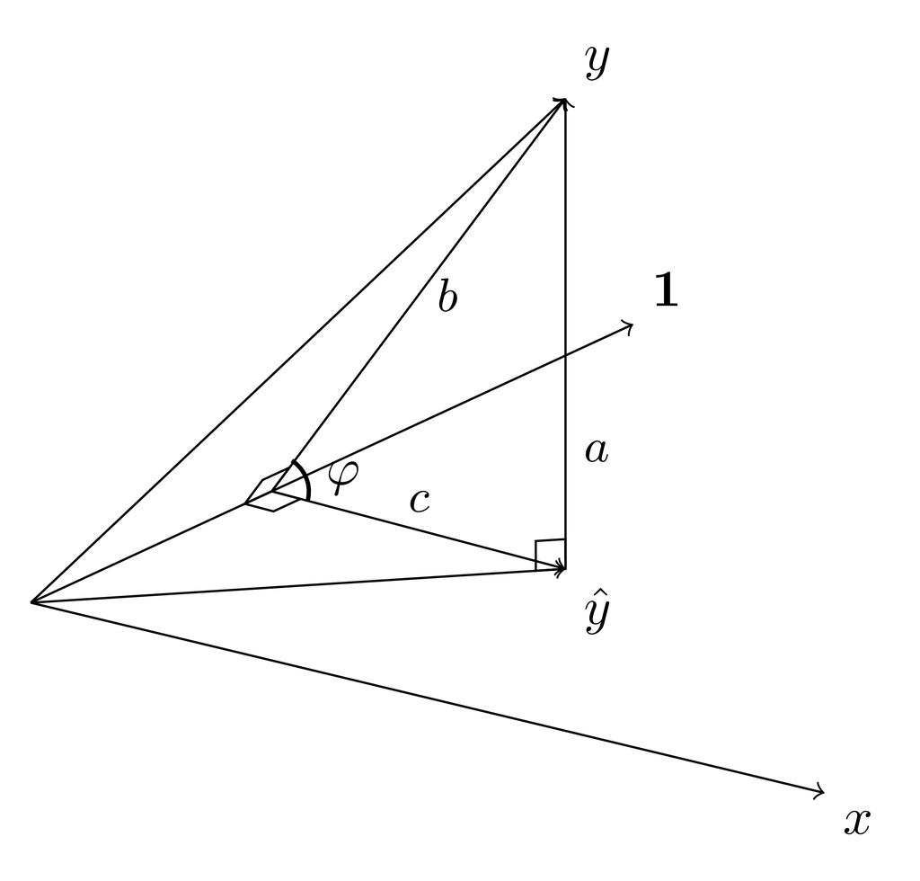

02_detremination_coefficient

[TeX](https://github.com/olyagnilova/gauss-markov-pythagoras/blob/master/figures/02_determination_coefficient.tex) [PDF](https://github.com/olyagnilova/gauss-markov-pythagoras/blob/master/figures/02_determination_coefficient.pdf) [PNG](https://github.com/olyagnilova/gauss-markov-pythagoras/blob/master/figures/02_determination_coefficient.png) [SVG](https://github.com/olyagnilova/gauss-markov-pythagoras/blob/master/figures/02_determination_coefficient.svg)

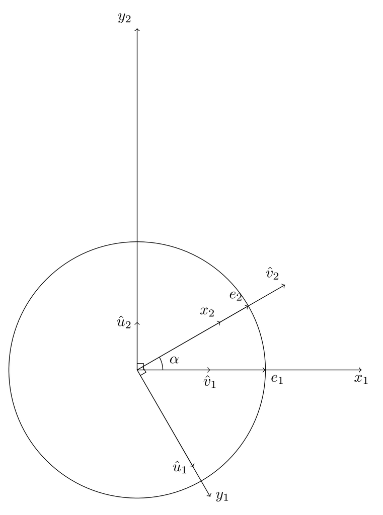

02_duality_final

[TeX](https://github.com/olyagnilova/gauss-markov-pythagoras/blob/master/figures/02_duality_final.tex) [PDF](https://github.com/olyagnilova/gauss-markov-pythagoras/blob/master/figures/02_duality_final.pdf) [PNG](https://github.com/olyagnilova/gauss-markov-pythagoras/blob/master/figures/02_duality_final.png) [SVG](https://github.com/olyagnilova/gauss-markov-pythagoras/blob/master/figures/02_duality_final.svg)

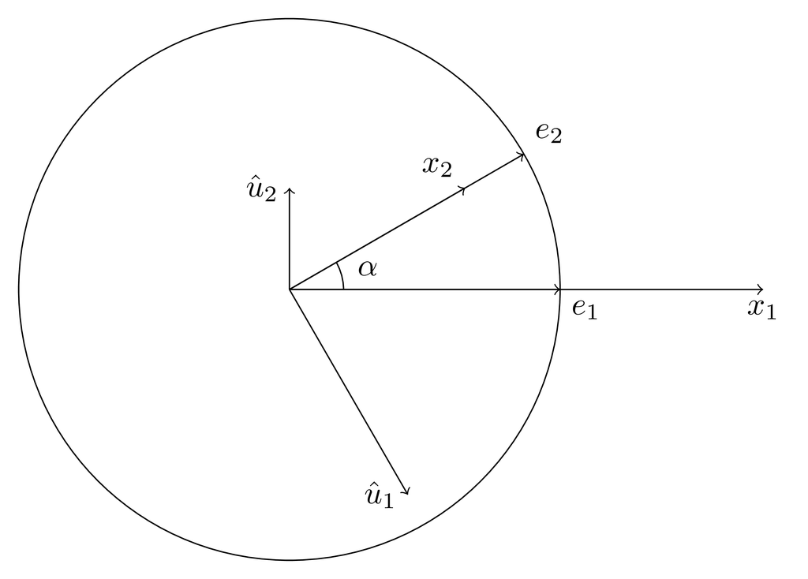

| 02_duality_first_residuals_translated | [TeX](https://github.com/olyagnilova/gauss-markov-pythagoras/blob/master/figures/02_duality_first_residuals_translated.tex) [PDF](https://github.com/olyagnilova/gauss-markov-pythagoras/blob/master/figures/02_duality_first_residuals_translated.pdf) [PNG](https://github.com/olyagnilova/gauss-markov-pythagoras/blob/master/figures/02_duality_first_residuals_translated.png) [SVG](https://github.com/olyagnilova/gauss-markov-pythagoras/blob/master/figures/02_duality_first_residuals_translated.svg)

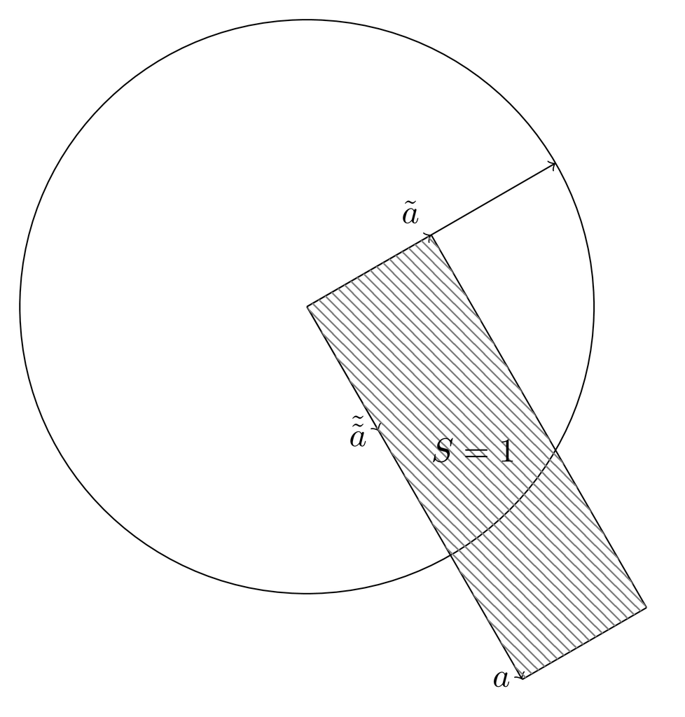

| 02_duality_inversion | [TeX](https://github.com/olyagnilova/gauss-markov-pythagoras/blob/master/figures/02_duality_inversion.tex) [PDF](https://github.com/olyagnilova/gauss-markov-pythagoras/blob/master/figures/02_duality_inversion.pdf) [PNG](https://github.com/olyagnilova/gauss-markov-pythagoras/blob/master/figures/02_duality_inversion.png) [SVG](https://github.com/olyagnilova/gauss-markov-pythagoras/blob/master/figures/02_duality_inversion.svg)

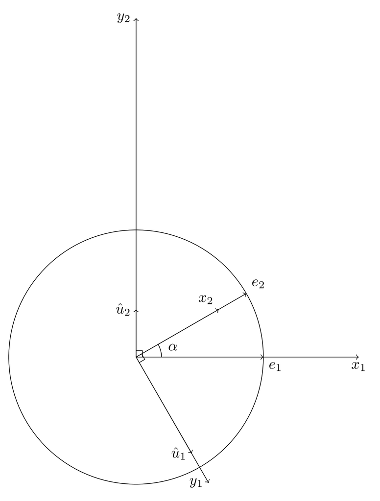

| 02_duality_new_regressors | [TeX](https://github.com/olyagnilova/gauss-markov-pythagoras/blob/master/figures/02_duality_new_regressors.tex) [PDF](https://github.com/olyagnilova/gauss-markov-pythagoras/blob/master/figures/02_duality_new_regressors.pdf) [PNG](https://github.com/olyagnilova/gauss-markov-pythagoras/blob/master/figures/02_duality_new_regressors.png) [SVG](https://github.com/olyagnilova/gauss-markov-pythagoras/blob/master/figures/02_duality_new_regressors.svg)

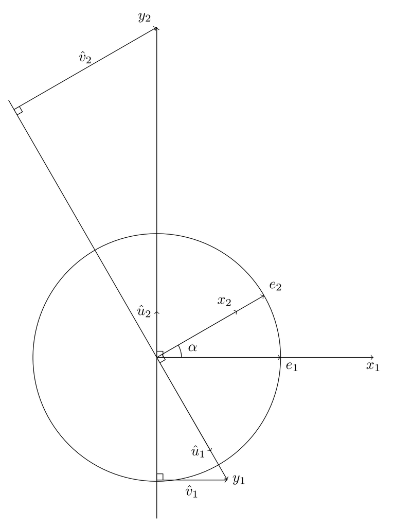

| 02_duality_new_residuals | [TeX](https://github.com/olyagnilova/gauss-markov-pythagoras/blob/master/figures/02_duality_new_residuals.tex) [PDF](https://github.com/olyagnilova/gauss-markov-pythagoras/blob/master/figures/02_duality_new_residuals.pdf) [PNG](https://github.com/olyagnilova/gauss-markov-pythagoras/blob/master/figures/02_duality_new_residuals.png) [SVG](https://github.com/olyagnilova/gauss-markov-pythagoras/blob/master/figures/02_duality_new_residuals.svg)

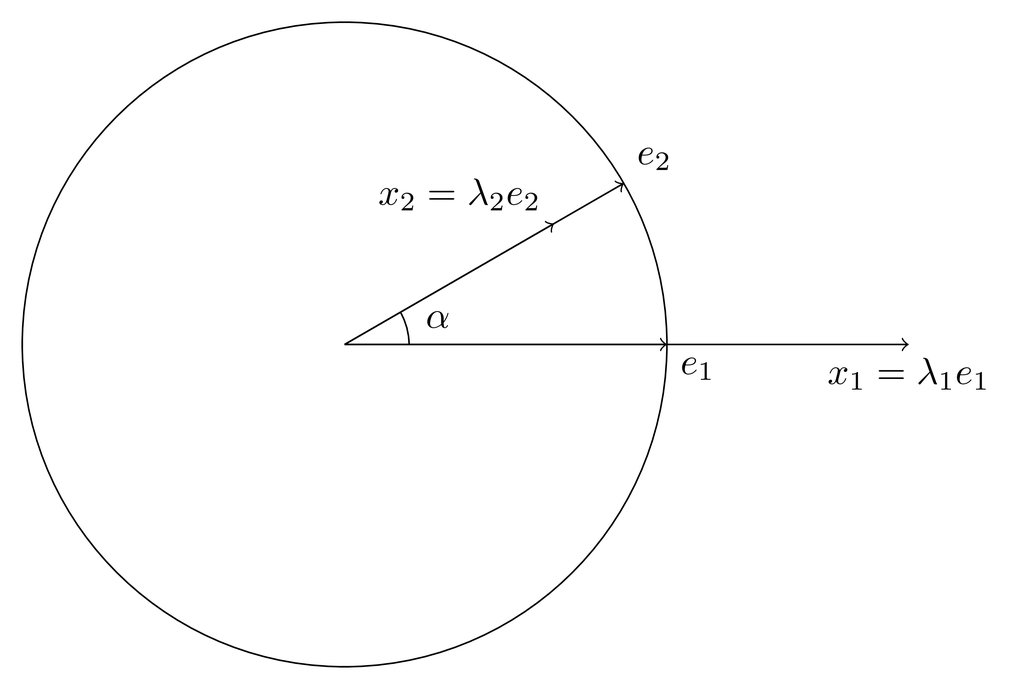

| 02_duality_original_regressors | [TeX](https://github.com/olyagnilova/gauss-markov-pythagoras/blob/master/figures/02_duality_original_regressors.tex) [PDF](https://github.com/olyagnilova/gauss-markov-pythagoras/blob/master/figures/02_duality_original_regressors.pdf) [PNG](https://github.com/olyagnilova/gauss-markov-pythagoras/blob/master/figures/02_duality_original_regressors.png) [SVG](https://github.com/olyagnilova/gauss-markov-pythagoras/blob/master/figures/02_duality_original_regressors.svg)

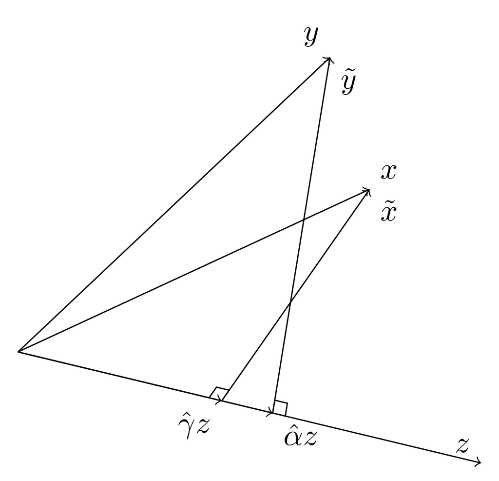

| 02_fwl_v1_cleansed_variables | [TeX](https://github.com/olyagnilova/gauss-markov-pythagoras/blob/master/figures/02_fwl_v1_cleansed_variables.tex) [PDF](https://github.com/olyagnilova/gauss-markov-pythagoras/blob/master/figures/02_fwl_v1_cleansed_variables.pdf) [PNG](https://github.com/olyagnilova/gauss-markov-pythagoras/blob/master/figures/02_fwl_v1_cleansed_variables.png) [SVG](https://github.com/olyagnilova/gauss-markov-pythagoras/blob/master/figures/02_fwl_v1_cleansed_variables.svg)

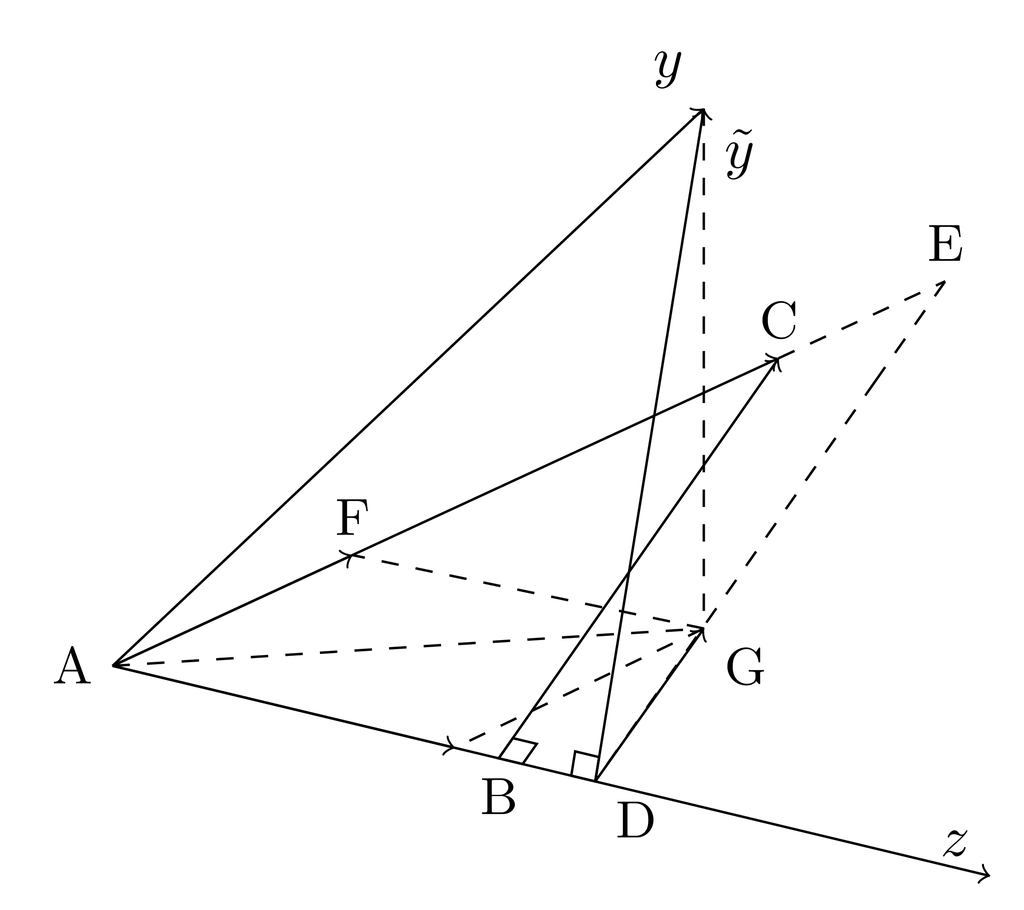

| 02_fwl_v1_final | [TeX](https://github.com/olyagnilova/gauss-markov-pythagoras/blob/master/figures/02_fwl_v1_final.tex) [PDF](https://github.com/olyagnilova/gauss-markov-pythagoras/blob/master/figures/02_fwl_v1_final.pdf) [PNG](https://github.com/olyagnilova/gauss-markov-pythagoras/blob/master/figures/02_fwl_v1_final.png) [SVG](https://github.com/olyagnilova/gauss-markov-pythagoras/blob/master/figures/02_fwl_v1_final.svg)

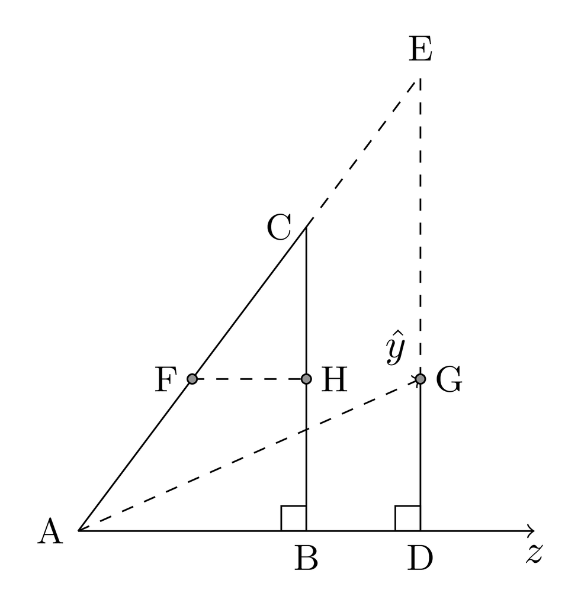

| 02_fwl_v1_final_lin | [TeX](https://github.com/olyagnilova/gauss-markov-pythagoras/blob/master/figures/02_fwl_v1_final_lin.tex) [PDF](https://github.com/olyagnilova/gauss-markov-pythagoras/blob/master/figures/02_fwl_v1_final_lin.pdf) [PNG](https://github.com/olyagnilova/gauss-markov-pythagoras/blob/master/figures/02_fwl_v1_final_lin.png) [SVG](https://github.com/olyagnilova/gauss-markov-pythagoras/blob/master/figures/02_fwl_v1_final_lin.svg)

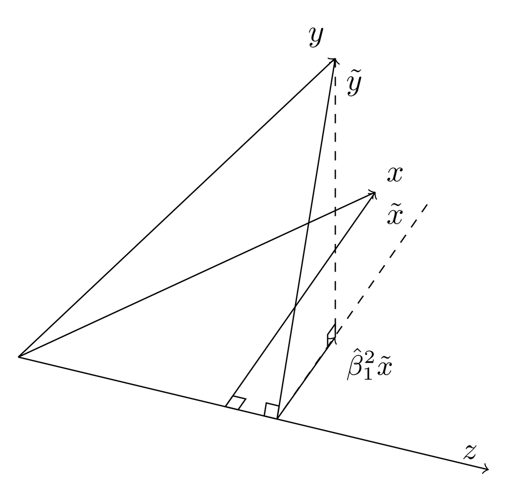

| 02_fwl_v1_translation | [TeX](https://github.com/olyagnilova/gauss-markov-pythagoras/blob/master/figures/02_fwl_v1_translation.tex) [PDF](https://github.com/olyagnilova/gauss-markov-pythagoras/blob/master/figures/02_fwl_v1_translation.pdf) [PNG](https://github.com/olyagnilova/gauss-markov-pythagoras/blob/master/figures/02_fwl_v1_translation.png) [SVG](https://github.com/olyagnilova/gauss-markov-pythagoras/blob/master/figures/02_fwl_v1_translation.svg)